# Part10

```python
import pandas as pd
import numpy as np
```

```python
df = pd.read_csv('D:\Pandas-Demo\part10\ETH_1h.csv')
```

```python
df.head()
```

|  | Date | Symbol | Open | High | Low | Close | Volume |
| --- | --- | --- | --- | --- | --- | --- | --- |
| 0 | 2020-03-13 08-PM | ETHUSD | 129.94 | 131.82 | 126.87 | 128.71 | 1940673.93 |
| 1 | 2020-03-13 07-PM | ETHUSD | 119.51 | 132.02 | 117.10 | 129.94 | 7579741.09 |
| 2 | 2020-03-13 06-PM | ETHUSD | 124.47 | 124.85 | 115.50 | 119.51 | 4898735.81 |
| 3 | 2020-03-13 05-PM | ETHUSD | 124.08 | 127.42 | 121.63 | 124.47 | 2753450.92 |
| 4 | 2020-03-13 04-PM | ETHUSD | 124.85 | 129.51 | 120.17 | 124.08 | 4461424.71 |

```python
df.shape
```

```
(23674, 7)
```

```python
df.describe()
```

|  | Open | High | Low | Close | Volume |
| --- | --- | --- | --- | --- | --- |
| count | 23674.000000 | 23674.000000 | 23674.000000 | 23674.000000 | 2.367400e+04 |
| mean | 324.933372 | 327.317109 | 322.255521 | 324.926601 | 2.011035e+06 |
| std | 236.189068 | 238.539115 | 233.365042 | 236.192308 | 3.673646e+06 |
| min | 81.290000 | 82.000000 | 80.600000 | 81.290000 | 0.000000e+00 |
| 25% | 171.522500 | 172.472500 | 170.500000 | 171.512500 | 3.993914e+05 |
| 50% | 229.745000 | 231.725000 | 228.100000 | 229.725000 | 9.146454e+05 |
| 75% | 402.797500 | 405.427500 | 400.030000 | 402.797500 | 2.098111e+06 |
| max | 1418.610000 | 1419.960000 | 1388.990000 | 1418.610000 | 8.569790e+07 |

```python
df.loc[0,'Date']
```

```
'2020-03-13 08-PM'
```

```python
df.loc[0,'Date'].day_name()
```

```
---------------------------------------------------------------------------
AttributeError                            Traceback (most recent call last)
Cell In[155], line 1
----> 1 df.loc[0,'Date'].day_name()

AttributeError: 'str' object has no attribute 'day_name'
```

之所以出现错误是因为字符串对象没有day_name属性。

```python
df['Date'] = pd.to_datetime(df['Date'])
```

[output not shown]

上面这样的str传导不符合形式，无法解析，具体形式见“[https://docs.python.org/3/library/datetime.html#strftime-and-strptime-behavior”。](https://docs.python.org/3/library/datetime.html#strftime-and-strptime-behavior%E2%80%9D%E3%80%82) 不用记，用什么样子查询pandas文档就行了。

```python
df['Date'] = pd.to_datetime(df['Date'],format='%Y-%m-%d %I-%p')
df.head()
```

|  | Date | Symbol | Open | High | Low | Close | Volume |
| --- | --- | --- | --- | --- | --- | --- | --- |
| 0 | 2020-03-13 20:00:00 | ETHUSD | 129.94 | 131.82 | 126.87 | 128.71 | 1940673.93 |
| 1 | 2020-03-13 19:00:00 | ETHUSD | 119.51 | 132.02 | 117.10 | 129.94 | 7579741.09 |
| 2 | 2020-03-13 18:00:00 | ETHUSD | 124.47 | 124.85 | 115.50 | 119.51 | 4898735.81 |
| 3 | 2020-03-13 17:00:00 | ETHUSD | 124.08 | 127.42 | 121.63 | 124.47 | 2753450.92 |
| 4 | 2020-03-13 16:00:00 | ETHUSD | 124.85 | 129.51 | 120.17 | 124.08 | 4461424.71 |

```python
df.loc[0,'Date'].day_name()
```

```
'Friday'
```

这样把str加载成日期格式就行了。 也可以在加载数据时候将其转换为日期，用parse dates argument。 在corey的视频中，可以直接pd.datetime.strptime()，但是我用需要重新导入datetime。 下面用的from datetime import datetime 是从datetime模块（module）中导入datetime类。 下面读取中的date_parser在pandas新版本中已经被标记废除了，开发团队建议用其他方法处理日期解析。

```python
import pandas as pd
from datetime import datetime
d_parser = lambda x: datetime.strptime(x,'%Y-%m-%d %I-%p')
df = pd.read_csv('D:\Pandas-Demo\part10\ETH_1h.csv',parse_dates=['Date'],date_parser = d_parser)
df.head()
```

## 下面是c推荐的写法。

```python
import pandas as pd

# 读取CSV文件，指定日期格式来解析'Date'列
df = pd.read_csv('D:\\Pandas-Demo\\part10\\ETH_1h.csv', parse_dates=['Date'], date_format='%Y-%m-%d %I-%p')

# 显示数据框的前几行
df.head()
```

|  | Date | Symbol | Open | High | Low | Close | Volume |
| --- | --- | --- | --- | --- | --- | --- | --- |
| 0 | 2020-03-13 20:00:00 | ETHUSD | 129.94 | 131.82 | 126.87 | 128.71 | 1940673.93 |
| 1 | 2020-03-13 19:00:00 | ETHUSD | 119.51 | 132.02 | 117.10 | 129.94 | 7579741.09 |
| 2 | 2020-03-13 18:00:00 | ETHUSD | 124.47 | 124.85 | 115.50 | 119.51 | 4898735.81 |
| 3 | 2020-03-13 17:00:00 | ETHUSD | 124.08 | 127.42 | 121.63 | 124.47 | 2753450.92 |
| 4 | 2020-03-13 16:00:00 | ETHUSD | 124.85 | 129.51 | 120.17 | 124.08 | 4461424.71 |

```python
df['Date'].dt
```

```
<pandas.core.indexes.accessors.DatetimeProperties object at 0x0000019E017DBC10>
```

```python
df['Date'].dt.day_name()
```

```
0          Friday
1          Friday
2          Friday
3          Friday
4          Friday
           ...
23669    Saturday
23670    Saturday
23671    Saturday
23672    Saturday
23673    Saturday
Name: Date, Length: 23674, dtype: object
```

```python
df['DayOfWeek']=df['Date'].dt.day_name()
df
```

|  | Date | Symbol | Open | High | Low | Close | Volume | DayOfWeek |
| --- | --- | --- | --- | --- | --- | --- | --- | --- |
| 0 | 2020-03-13 20:00:00 | ETHUSD | 129.94 | 131.82 | 126.87 | 128.71 | 1940673.93 | Friday |
| 1 | 2020-03-13 19:00:00 | ETHUSD | 119.51 | 132.02 | 117.10 | 129.94 | 7579741.09 | Friday |
| 2 | 2020-03-13 18:00:00 | ETHUSD | 124.47 | 124.85 | 115.50 | 119.51 | 4898735.81 | Friday |
| 3 | 2020-03-13 17:00:00 | ETHUSD | 124.08 | 127.42 | 121.63 | 124.47 | 2753450.92 | Friday |
| 4 | 2020-03-13 16:00:00 | ETHUSD | 124.85 | 129.51 | 120.17 | 124.08 | 4461424.71 | Friday |
| ... | ... | ... | ... | ... | ... | ... | ... | ... |
| 23669 | 2017-07-01 15:00:00 | ETHUSD | 265.74 | 272.74 | 265.00 | 272.57 | 1500282.55 | Saturday |
| 23670 | 2017-07-01 14:00:00 | ETHUSD | 268.79 | 269.90 | 265.00 | 265.74 | 1702536.85 | Saturday |
| 23671 | 2017-07-01 13:00:00 | ETHUSD | 274.83 | 274.93 | 265.00 | 268.79 | 3010787.99 | Saturday |
| 23672 | 2017-07-01 12:00:00 | ETHUSD | 275.01 | 275.01 | 271.00 | 274.83 | 824362.87 | Saturday |
| 23673 | 2017-07-01 11:00:00 | ETHUSD | 279.98 | 279.99 | 272.10 | 275.01 | 679358.87 | Saturday |

23674 rows × 8 columns

```python
df['Date'].min()
```

```
Timestamp('2017-07-01 11:00:00')
```

```python
df['Date'].max()
```

```
Timestamp('2020-03-13 20:00:00')
```

```python
df['Date'].max() - df['Date'].min()
```

```
Timedelta('986 days 09:00:00')
```

```python
filt = (df['Date'] >= '2020')
df.loc[filt]
```

|  | Date | Symbol | Open | High | Low | Close | Volume | DayOfWeek |
| --- | --- | --- | --- | --- | --- | --- | --- | --- |
| 0 | 2020-03-13 20:00:00 | ETHUSD | 129.94 | 131.82 | 126.87 | 128.71 | 1940673.93 | Friday |
| 1 | 2020-03-13 19:00:00 | ETHUSD | 119.51 | 132.02 | 117.10 | 129.94 | 7579741.09 | Friday |
| 2 | 2020-03-13 18:00:00 | ETHUSD | 124.47 | 124.85 | 115.50 | 119.51 | 4898735.81 | Friday |
| 3 | 2020-03-13 17:00:00 | ETHUSD | 124.08 | 127.42 | 121.63 | 124.47 | 2753450.92 | Friday |
| 4 | 2020-03-13 16:00:00 | ETHUSD | 124.85 | 129.51 | 120.17 | 124.08 | 4461424.71 | Friday |
| ... | ... | ... | ... | ... | ... | ... | ... | ... |
| 1744 | 2020-01-01 04:00:00 | ETHUSD | 129.57 | 130.00 | 129.50 | 129.56 | 702786.82 | Wednesday |
| 1745 | 2020-01-01 03:00:00 | ETHUSD | 130.37 | 130.44 | 129.38 | 129.57 | 496704.23 | Wednesday |
| 1746 | 2020-01-01 02:00:00 | ETHUSD | 130.14 | 130.50 | 129.91 | 130.37 | 396315.72 | Wednesday |
| 1747 | 2020-01-01 01:00:00 | ETHUSD | 128.34 | 130.14 | 128.32 | 130.14 | 635419.40 | Wednesday |
| 1748 | 2020-01-01 00:00:00 | ETHUSD | 128.54 | 128.54 | 128.12 | 128.34 | 245119.91 | Wednesday |

1749 rows × 8 columns

```python
filt = (df['Date'] >= '2019') &  (df['Date'] < '2020')
df.loc[filt]
```

|  | Date | Symbol | Open | High | Low | Close | Volume | DayOfWeek |
| --- | --- | --- | --- | --- | --- | --- | --- | --- |
| 1749 | 2019-12-31 23:00:00 | ETHUSD | 128.33 | 128.69 | 128.14 | 128.54 | 440678.91 | Tuesday |
| 1750 | 2019-12-31 22:00:00 | ETHUSD | 128.38 | 128.69 | 127.95 | 128.33 | 554646.02 | Tuesday |
| 1751 | 2019-12-31 21:00:00 | ETHUSD | 127.86 | 128.43 | 127.72 | 128.38 | 350155.69 | Tuesday |
| 1752 | 2019-12-31 20:00:00 | ETHUSD | 127.84 | 128.34 | 127.71 | 127.86 | 428183.38 | Tuesday |
| 1753 | 2019-12-31 19:00:00 | ETHUSD | 128.69 | 128.69 | 127.60 | 127.84 | 1169847.84 | Tuesday |
| ... | ... | ... | ... | ... | ... | ... | ... | ... |
| 10504 | 2019-01-01 04:00:00 | ETHUSD | 130.75 | 133.96 | 130.74 | 131.96 | 2791135.37 | Tuesday |
| 10505 | 2019-01-01 03:00:00 | ETHUSD | 130.06 | 130.79 | 130.06 | 130.75 | 503732.63 | Tuesday |
| 10506 | 2019-01-01 02:00:00 | ETHUSD | 130.79 | 130.88 | 129.55 | 130.06 | 838183.43 | Tuesday |
| 10507 | 2019-01-01 01:00:00 | ETHUSD | 131.62 | 131.62 | 130.77 | 130.79 | 434917.99 | Tuesday |
| 10508 | 2019-01-01 00:00:00 | ETHUSD | 130.53 | 131.91 | 130.48 | 131.62 | 1067136.21 | Tuesday |

8760 rows × 8 columns

croey视频中用pd.datetime，在新版本中没法在使用了所以下面的是不行的。

```python
from datetime import datetime
filt = (df['Date'] >= pd.datetime('2019-01-01')) &  (df['Date'] < pd.datetime('2020-01-01'))
df.loc[filt]
```

```
---------------------------------------------------------------------------
AttributeError                            Traceback (most recent call last)
Cell In[168], line 2
      1 from datetime import datetime
----> 2 filt = (df['Date'] >= pd.datetime('2019-01-01')) &  (df['Date'] < pd.datetime('2020-01-01'))
      3 df.loc[filt]

AttributeError: module 'pandas' has no attribute 'datetime'
```

C推荐写法，using pandas's pd.to_datetime

```python
filt = (df['Date'] >= pd.to_datetime('2019-01-01')) &  (df['Date'] < pd.to_datetime('2020-01-01'))
df.loc[filt]
```

|  | Date | Symbol | Open | High | Low | Close | Volume | DayOfWeek |
| --- | --- | --- | --- | --- | --- | --- | --- | --- |
| 1749 | 2019-12-31 23:00:00 | ETHUSD | 128.33 | 128.69 | 128.14 | 128.54 | 440678.91 | Tuesday |
| 1750 | 2019-12-31 22:00:00 | ETHUSD | 128.38 | 128.69 | 127.95 | 128.33 | 554646.02 | Tuesday |
| 1751 | 2019-12-31 21:00:00 | ETHUSD | 127.86 | 128.43 | 127.72 | 128.38 | 350155.69 | Tuesday |
| 1752 | 2019-12-31 20:00:00 | ETHUSD | 127.84 | 128.34 | 127.71 | 127.86 | 428183.38 | Tuesday |
| 1753 | 2019-12-31 19:00:00 | ETHUSD | 128.69 | 128.69 | 127.60 | 127.84 | 1169847.84 | Tuesday |
| ... | ... | ... | ... | ... | ... | ... | ... | ... |
| 10504 | 2019-01-01 04:00:00 | ETHUSD | 130.75 | 133.96 | 130.74 | 131.96 | 2791135.37 | Tuesday |
| 10505 | 2019-01-01 03:00:00 | ETHUSD | 130.06 | 130.79 | 130.06 | 130.75 | 503732.63 | Tuesday |
| 10506 | 2019-01-01 02:00:00 | ETHUSD | 130.79 | 130.88 | 129.55 | 130.06 | 838183.43 | Tuesday |
| 10507 | 2019-01-01 01:00:00 | ETHUSD | 131.62 | 131.62 | 130.77 | 130.79 | 434917.99 | Tuesday |
| 10508 | 2019-01-01 00:00:00 | ETHUSD | 130.53 | 131.91 | 130.48 | 131.62 | 1067136.21 | Tuesday |

8760 rows × 8 columns

```python
df.set_index('Date',inplace=True)
df
```

| Date | Symbol | Open | High | Low | Close | Volume | DayOfWeek |
| --- | --- | --- | --- | --- | --- | --- | --- |
| 2020-03-13 20:00:00 | ETHUSD | 129.94 | 131.82 | 126.87 | 128.71 | 1940673.93 | Friday |
| 2020-03-13 19:00:00 | ETHUSD | 119.51 | 132.02 | 117.10 | 129.94 | 7579741.09 | Friday |
| 2020-03-13 18:00:00 | ETHUSD | 124.47 | 124.85 | 115.50 | 119.51 | 4898735.81 | Friday |
| 2020-03-13 17:00:00 | ETHUSD | 124.08 | 127.42 | 121.63 | 124.47 | 2753450.92 | Friday |
| 2020-03-13 16:00:00 | ETHUSD | 124.85 | 129.51 | 120.17 | 124.08 | 4461424.71 | Friday |
| ... | ... | ... | ... | ... | ... | ... | ... |
| 2017-07-01 15:00:00 | ETHUSD | 265.74 | 272.74 | 265.00 | 272.57 | 1500282.55 | Saturday |
| 2017-07-01 14:00:00 | ETHUSD | 268.79 | 269.90 | 265.00 | 265.74 | 1702536.85 | Saturday |
| 2017-07-01 13:00:00 | ETHUSD | 274.83 | 274.93 | 265.00 | 268.79 | 3010787.99 | Saturday |
| 2017-07-01 12:00:00 | ETHUSD | 275.01 | 275.01 | 271.00 | 274.83 | 824362.87 | Saturday |
| 2017-07-01 11:00:00 | ETHUSD | 279.98 | 279.99 | 272.10 | 275.01 | 679358.87 | Saturday |

23674 rows × 7 columns

corey是用的df['2019'] 试了不行，还是需要用loc

```python
df.loc['2019']
```

| Date | Symbol | Open | High | Low | Close | Volume | DayOfWeek |
| --- | --- | --- | --- | --- | --- | --- | --- |
| 2019-12-31 23:00:00 | ETHUSD | 128.33 | 128.69 | 128.14 | 128.54 | 440678.91 | Tuesday |
| 2019-12-31 22:00:00 | ETHUSD | 128.38 | 128.69 | 127.95 | 128.33 | 554646.02 | Tuesday |
| 2019-12-31 21:00:00 | ETHUSD | 127.86 | 128.43 | 127.72 | 128.38 | 350155.69 | Tuesday |
| 2019-12-31 20:00:00 | ETHUSD | 127.84 | 128.34 | 127.71 | 127.86 | 428183.38 | Tuesday |
| 2019-12-31 19:00:00 | ETHUSD | 128.69 | 128.69 | 127.60 | 127.84 | 1169847.84 | Tuesday |
| ... | ... | ... | ... | ... | ... | ... | ... |
| 2019-01-01 04:00:00 | ETHUSD | 130.75 | 133.96 | 130.74 | 131.96 | 2791135.37 | Tuesday |
| 2019-01-01 03:00:00 | ETHUSD | 130.06 | 130.79 | 130.06 | 130.75 | 503732.63 | Tuesday |
| 2019-01-01 02:00:00 | ETHUSD | 130.79 | 130.88 | 129.55 | 130.06 | 838183.43 | Tuesday |
| 2019-01-01 01:00:00 | ETHUSD | 131.62 | 131.62 | 130.77 | 130.79 | 434917.99 | Tuesday |
| 2019-01-01 00:00:00 | ETHUSD | 130.53 | 131.91 | 130.48 | 131.62 | 1067136.21 | Tuesday |

8760 rows × 7 columns

```python
df.loc[['2020-01':'2020-02']]
```

```
  Cell In[185], line 1
    df.loc[['2020-01':'2020-02']]
                     ^
SyntaxError: invalid syntax
```

```python
# Check if the index is monotonic
print(df.index.is_monotonic_increasing)
```

```
False
```

```python
df.sort_index(inplace=True)
```

```python
df.loc['2020-01':'2020-02']
```

| Date | Symbol | Open | High | Low | Close | Volume | DayOfWeek |
| --- | --- | --- | --- | --- | --- | --- | --- |
| 2020-01-01 00:00:00 | ETHUSD | 128.54 | 128.54 | 128.12 | 128.34 | 245119.91 | Wednesday |
| 2020-01-01 01:00:00 | ETHUSD | 128.34 | 130.14 | 128.32 | 130.14 | 635419.40 | Wednesday |
| 2020-01-01 02:00:00 | ETHUSD | 130.14 | 130.50 | 129.91 | 130.37 | 396315.72 | Wednesday |
| 2020-01-01 03:00:00 | ETHUSD | 130.37 | 130.44 | 129.38 | 129.57 | 496704.23 | Wednesday |
| 2020-01-01 04:00:00 | ETHUSD | 129.57 | 130.00 | 129.50 | 129.56 | 702786.82 | Wednesday |
| ... | ... | ... | ... | ... | ... | ... | ... |
| 2020-02-29 19:00:00 | ETHUSD | 225.09 | 225.85 | 223.87 | 225.31 | 1250856.20 | Saturday |
| 2020-02-29 20:00:00 | ETHUSD | 225.31 | 225.33 | 223.50 | 224.63 | 511648.65 | Saturday |
| 2020-02-29 21:00:00 | ETHUSD | 224.63 | 225.14 | 222.74 | 223.48 | 561158.03 | Saturday |
| 2020-02-29 22:00:00 | ETHUSD | 223.48 | 223.59 | 222.14 | 223.35 | 535998.57 | Saturday |
| 2020-02-29 23:00:00 | ETHUSD | 223.35 | 223.58 | 216.83 | 217.31 | 1927939.88 | Saturday |

1440 rows × 7 columns

```python
c的意见是需要sort  index，然后在切片：，但不管是那种，df['2020']是不行的。
```

```python
df.loc['2020-01':'2020-02']['Close'].mean()
```

```
np.float64(195.1655902777778)
```

```python
df.loc['2020-01-01']['High']
```

```
Date
2020-01-01 00:00:00    128.54
2020-01-01 01:00:00    130.14
2020-01-01 02:00:00    130.50
2020-01-01 03:00:00    130.44
2020-01-01 04:00:00    130.00
2020-01-01 05:00:00    129.94
2020-01-01 06:00:00    130.25
2020-01-01 07:00:00    130.25
2020-01-01 08:00:00    130.01
2020-01-01 09:00:00    130.22
2020-01-01 10:00:00    130.33
2020-01-01 11:00:00    131.42
2020-01-01 12:00:00    131.31
2020-01-01 13:00:00    132.08
2020-01-01 14:00:00    132.05
2020-01-01 15:00:00    132.15
2020-01-01 16:00:00    132.56
2020-01-01 17:00:00    132.68
2020-01-01 18:00:00    132.14
2020-01-01 19:00:00    131.72
2020-01-01 20:00:00    131.87
2020-01-01 21:00:00    131.99
2020-01-01 22:00:00    131.41
2020-01-01 23:00:00    130.27
Name: High, dtype: float64
```

```python
df.loc['2020-01-01']['High'].max()
```

```
np.float64(132.68)
```

用resample来分类，这样类似分类聚合，但是更简单。原始表格是用H来计的。

```python
highs = df['High'].resample('D').max()
highs['2020-01-01']
```

```
np.float64(132.68)
```

```python
%matplotlib inline
```

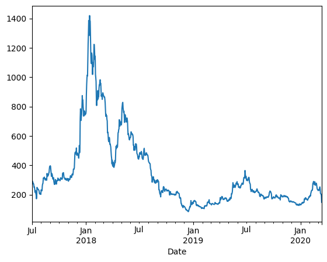

```python
highs.plot()
```

按视频中的corey如果直接使用df.resample().mean()，数据中的非数字数据会导致mean执行。 下面需要中df[[]]来选择数字数据。

```python
df[['Open','High','Low','Close','Volume']].resample('W').mean()
```

| Date | Open | High | Low | Close | Volume |
| --- | --- | --- | --- | --- | --- |
| 2017-07-02 | 268.066486 | 271.124595 | 264.819730 | 268.202162 | 2.185035e+06 |
| 2017-07-09 | 261.337024 | 262.872917 | 259.186190 | 261.062083 | 1.337349e+06 |
| 2017-07-16 | 196.193214 | 199.204405 | 192.722321 | 195.698393 | 2.986756e+06 |
| 2017-07-23 | 212.351429 | 215.779286 | 209.126310 | 212.783750 | 4.298593e+06 |
| 2017-07-30 | 203.496190 | 205.110357 | 201.714048 | 203.309524 | 1.581729e+06 |
| ... | ... | ... | ... | ... | ... |
| 2020-02-16 | 255.021667 | 257.255238 | 252.679762 | 255.198452 | 2.329087e+06 |
| 2020-02-23 | 265.220833 | 267.263690 | 262.948512 | 265.321905 | 1.826094e+06 |
| 2020-03-01 | 236.720536 | 238.697500 | 234.208750 | 236.373988 | 2.198762e+06 |
| 2020-03-08 | 229.923571 | 231.284583 | 228.373810 | 229.817619 | 1.628910e+06 |
| 2020-03-15 | 176.937521 | 179.979487 | 172.936239 | 176.332821 | 4.259828e+06 |

142 rows × 5 columns

下面相当于是周报的汇总。

```python
df.resample('W').agg({'Close':'mean','High':'max','Low':'min','Volume':'sum'})
```

| Date | Close | High | Low | Volume |
| --- | --- | --- | --- | --- |
| 2017-07-02 | 268.202162 | 293.73 | 253.23 | 8.084631e+07 |
| 2017-07-09 | 261.062083 | 285.00 | 231.25 | 2.246746e+08 |
| 2017-07-16 | 195.698393 | 240.33 | 130.26 | 5.017750e+08 |
| 2017-07-23 | 212.783750 | 249.40 | 153.25 | 7.221637e+08 |
| 2017-07-30 | 203.309524 | 229.99 | 178.03 | 2.657305e+08 |
| ... | ... | ... | ... | ... |
| 2020-02-16 | 255.198452 | 290.00 | 216.31 | 3.912867e+08 |
| 2020-02-23 | 265.321905 | 287.13 | 242.36 | 3.067838e+08 |
| 2020-03-01 | 236.373988 | 278.13 | 209.26 | 3.693920e+08 |
| 2020-03-08 | 229.817619 | 253.01 | 196.00 | 2.736569e+08 |
| 2020-03-15 | 176.332821 | 208.65 | 90.00 | 4.983998e+08 |

142 rows × 4 columns